# Comparing Air Quality Trends: Champaign County, IL vs. India

Suchita Bhandari

2025-05-08

## Project Overview

Air quality is a major factor in evaluating quality of life in a given location. I moved to the US from India at age four and visited again last year; I also visited family friends near Champaign County, Illinois. This project compares air quality in these two locations and examines how specific pollutants (PM2.5, PM10) relate to overall air quality risk.

## Data sources

- `air-quality-champaign-county.csv` — annual counts of days with less-than-moderate air quality in Champaign County, IL
- `Dataset_AQI4-5.xlsx` — daily air quality index (AQI) and pollutant readings for cities across India

```r
champaign_data <- read.csv("air-quality-champaign-county.csv")
india_data <- read_excel("Dataset_AQI4-5.xlsx")
```

## Data Cleaning

Both datasets required renaming, type conversion, and date parsing before analysis.

```r
# Rename for clarity
champaign_data <- champaign_data %>%
  rename(days_rated_less_than_moderate = Days.Rated.Less.than.Moderate)

india_data <- india_data %>%
  rename(
    air_quality = AQI,
    pm2_5 = PM2.5,
    pm_10 = PM10
  )

# Standardize city names; transliterate non-Latin characters so plot labels render
india_data <- india_data %>%
  mutate(
    city = gsub(",", "", City),
    city = iconv(city, to = "ASCII//TRANSLIT")
  )

# Parse datetimes: Time is "YYYY-MM-DD HH:MM:SS" (24-hour clock),
# which ymd_hms() handles exactly
india_data <- india_data %>%
  mutate(date = as.Date(ymd_hms(Time, quiet = TRUE)))

stopifnot(
  "No usable dates parsed from the Time column - inspect it with head(Time)" =
    sum(!is.na(india_data$date)) > 0
)

# Standardize column names
india_data <- india_data %>%
  clean_names()

# Convert pollutant columns to numeric, treating "-" as missing
india_data <- india_data %>%
  mutate(
    air_quality = as.numeric(ifelse(air_quality == "-", NA, air_quality)),
    across(c(pm2_5, pm_10, o3, no2, so2, co),
           ~ suppressWarnings(as.numeric(na_if(as.character(.x), "-"))))
  )
```

## Champaign County: Air Quality Over Time

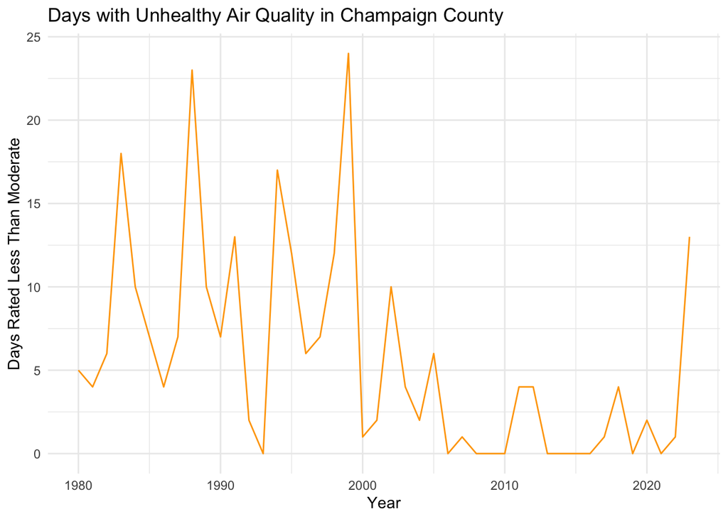

```r
ggplot(champaign_data, aes(x = Year, y = days_rated_less_than_moderate)) +
  geom_line(col = "orange") +
  labs(
    title = "Days with Unhealthy Air Quality in Champaign County",
    x = "Year", y = "Days Rated Less Than Moderate"
  ) +
  theme_minimal()
```

This graph tracks how air quality has changed in Champaign County over time. The trend fluctuates but declines overall, indicating a period of relatively low pollution. In more recent years, however, the count of unhealthy air quality days appears to be rising again, suggesting a possible reversal and continued environmental challenges.

## India: Air Quality by City

[figure not shown]

```r
top_cities <- india_data %>%
  arrange(desc(air_quality)) %>%
  slice_head(n = 20)

ggplot(top_cities, aes(x = reorder(city, air_quality), y = air_quality)) +
  geom_col(fill = "orange") +
  coord_flip() +
  labs(title = "Air Quality in India by City", x = "City", y = "Air Quality Index") +
  theme_minimal()
```

## India: Pollutant Concentration Over Time

[figure not shown]

```r
clean_data <- india_data %>%
  select(date, pm2_5, pm_10) %>%
  pivot_longer(
    cols = c("pm2_5", "pm_10"),
    names_to = "pollutant",
    values_to = "value"
  ) %>%
  mutate(pollutant = recode(pollutant, "pm2_5" = "PM2.5", "pm_10" = "PM10")) %>%
  filter(!is.na(value), !is.na(date))

plot1 <- ggplot(clean_data, aes(x = date, y = value, color = pollutant, group = pollutant)) +
  geom_line() +
  labs(
    title = "Air Quality in India Over Time",
    x = "Date", y = "Pollutant Concentration", color = "Pollutant"
  ) +
  theme_minimal() +
  transition_reveal(date)

animate(plot1)
```